# Statistical Machine Learning: Midterm Report

Oussama Azizi A07922203

# 1. Exploratory Data Analysis

We look at the summary of the data :

```
##      Income           Limit           Rating          Cards
##  Min.   : 10.35   Min.   :  855   Min.   : 93.0   Min.   :1.000
##  1st Qu.: 21.01   1st Qu.: 3088   1st Qu.:247.2   1st Qu.:2.000
##  Median : 33.12   Median : 4622   Median :344.0   Median :3.000
##  Mean   : 45.22   Mean   : 4736   Mean   :354.9   Mean   :2.958
##  3rd Qu.: 57.47   3rd Qu.: 5873   3rd Qu.:437.2   3rd Qu.:4.000
##  Max.   :186.63   Max.   :13913   Max.   :982.0   Max.   :9.000
##       Age          Education        Gender    Student   Married
##  Min.   :23.00   Min.   : 5.00   Female:207   No :360   No :155
##  1st Qu.:41.75   1st Qu.:11.00   Male  :193   Yes: 40   Yes:245
##  Median :56.00   Median :14.00
##  Mean   :55.67   Mean   :13.45
##  3rd Qu.:70.00   3rd Qu.:16.00
##  Max.   :98.00   Max.   :20.00
##             Ethnicity      Balance
##  African American: 99   Min.   :   0.00
##  Asian           :102   1st Qu.:  68.75
##  Caucasian       :199   Median : 459.50
##                         Mean   : 520.01
##                         3rd Qu.: 863.00
##                         Max.   :1999.00
```

We notice that the classes are imbalanced : Indeed, $50\%$ of participants are Caucasians, and only $25\%$ are African American and $25\%$ Asian. To address this issue, we perform the Synthetic Minority Over-sampling Technique (SMOTE) and we obtain the following result :

```
## African American            Asian        Caucasian
##              297              133              263
```

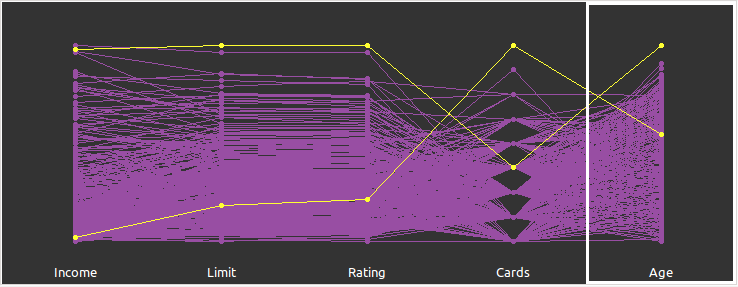

We notice that the observation $324$ and $384$ are potential outliers, we hence delete them from the dataset. We use the z-standardization to normalize the data for algorithms that are sensitive to scaling such as SVM for which features with higher variance have larger effect on the margin. We plot boxplots for each explanatory variable:

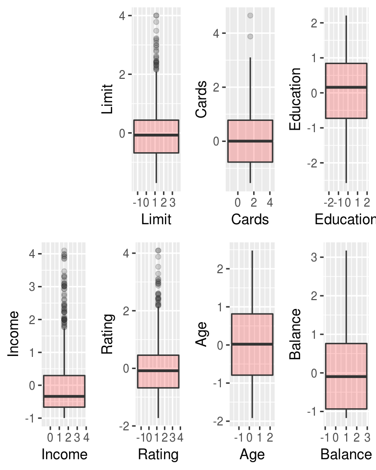

We conclude that there are few leverage points but we won’t drop them since they don’t affect that much the results compared to outliers. We plot the histograms for each explanatory variable for each class :

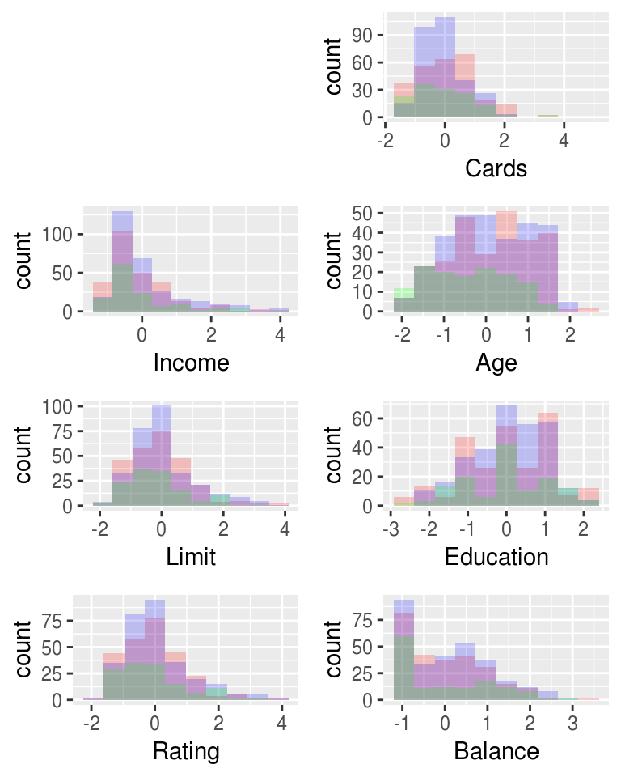

The first observation that we notice is that all the classes overlap for every explanatory variable, which might be an indicator of bad explanatory variables selection. This will make the classification process difficult to achieve and will lead to very poor performance as we will see. To confirm this, we use the T-distributed Stochastic Neighbor Embedding (T-SNE) to visualize the data in 2 dimensions:

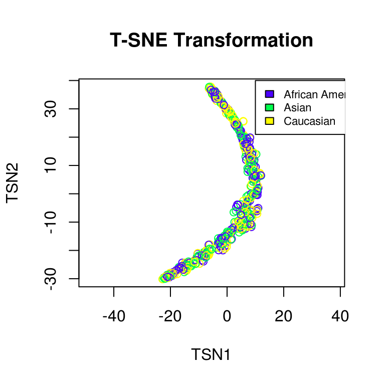

The second observation is that the distribution of features for each class are either right skewed or left skewed which violates the multivariate normality assumption, since joint normality implies marginal one.

# 2. Single Learners

For each single classifier,we use 10-fold Cross-validation to estimate the true error and we use the latter as a metric to compare between these models. The ROC would have been a good metric if we didn’t solve the problem of imbalanced classes and if we had only two classes.

## 2.1. LDA and QDA

### Checking LDA and QDA assumptions

LDA and QDA requires that the predictors are normally distributed for each class. As we have seen from the histograms of features, the distributions are either left or right skewed but not normal. We perform a Mardia’s test to make sure that it is the case :

```
##              Test        Statistic               p value Result
## 1 Mardia Skewness 875.299004709567 5.43999099243476e-132     NO
## 2 Mardia Kurtosis 3.01542845755448   0.00256616470035986     NO
## 3             MVN             <NA>                  <NA>     NO
```

As we see, the predictors marginal distribution didn’t pass the Mardia’s test for kurtosis nor the skewness one for normality. Another condition is that the covariance matrix should be the same for the outcome across all class groups.

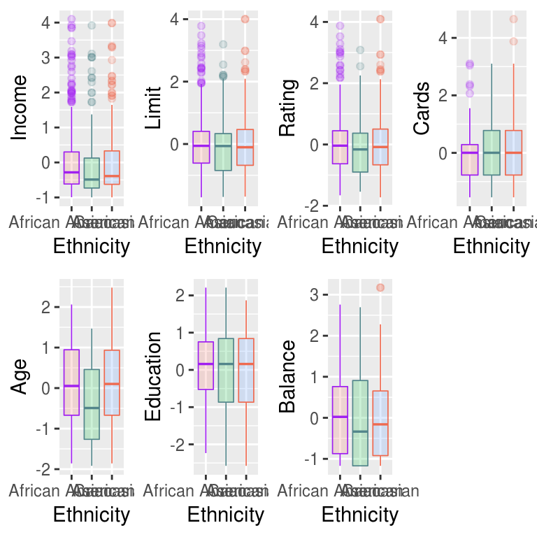

```
##
##  Box's M-test for Homogeneity of Covariance Matrices
##
## data:  credit2[features]
## Chi-Sq (approx.) = 184.77, df = 56, p-value = 1.148e-15
```

We can clearly see that the $p-value << 0.05$ which indicates high evidence against the null hypothesis $H_0 : The \space covariance \space matrices \space of \space the \space Ethnicity \space variable \space are \space equal \space across \space all \space groups \space .$ We can also perform a Levene’s test which is more relevant since the data is not normal:

```
## [1] "Cards~Ethnicity"
```

```
## Levene's Test for Homogeneity of Variance (center = median)
##        Df F value    Pr(>F)
## group   2  14.216 8.908e-07 ***
##       690
## ---
## Signif. codes:  0 '***' 0.001 '**' 0.01 '*' 0.05 '.' 0.1 ' ' 1
```

```
## [1] "Balance~Ethnicity"
```

```
## Levene's Test for Homogeneity of Variance (center = median)
##        Df F value Pr(>F)
## group   2  1.7891 0.1679
##       690
```

```
## [1] "Age~Ethnicity"
```

```
## Levene's Test for Homogeneity of Variance (center = median)
##        Df F value Pr(>F)
## group   2  0.1243 0.8832
##       690
```

```
## [1] "Rating~Ethnicity"
```

```
## Levene's Test for Homogeneity of Variance (center = median)
##        Df F value Pr(>F)
## group   2   0.294 0.7454
##       690
```

We conclude that apart from the variable $Cards$ the covariances seem to be homogenious. Again the homogeneous covariance assumption is violated. We should expect the LDA to perform bad and QDA better since it is not affected by the variance-covariance heterogeneity. We perform 10-fold Cross validation to estimate the true error of both LDA and QDA. We plot the confusion matrix for both classifiers :

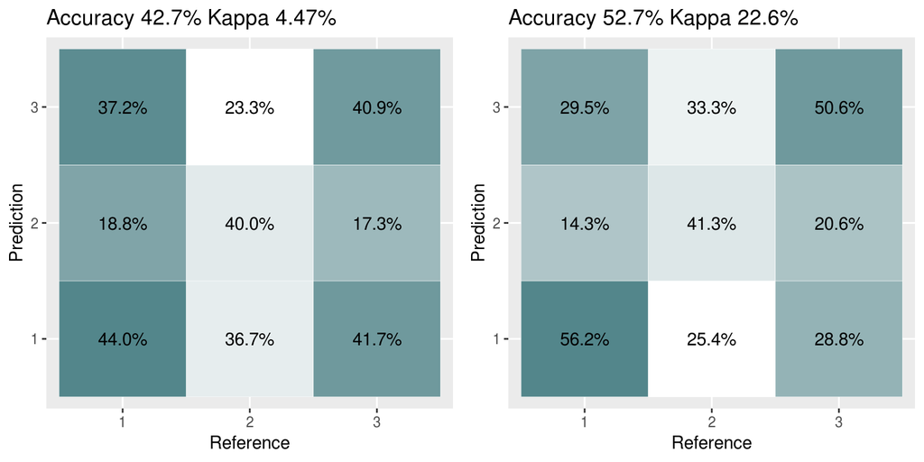

## 2.2. Support Vector Machine

We use the default settings for kernel for SVM, and a 10-fold cross validation to find the best values for the parameter $\gamma$ and the cost $c$. To serve this purpose, we make a grid search for the best $(c,\gamma)$ in the space $[0.1,15] \times [0.5,5]$.

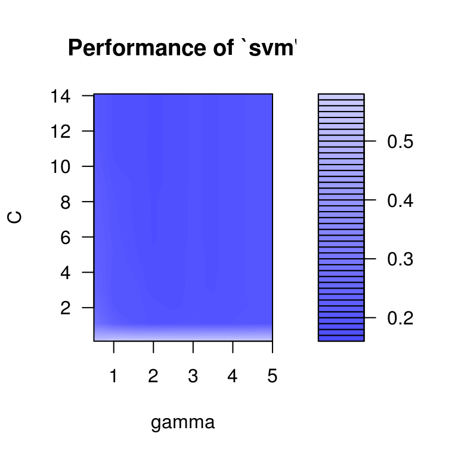

The best value of the pair $(c,\gamma)$ is $(6.1,2)$ which leads to an apparent error of $15.15\%$. We test the model on the test set. We obtain the confusion matrix resulting of the 10-fold cross validation :

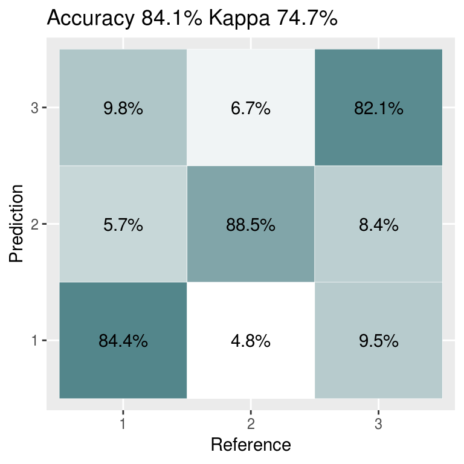

According to the 10-fold Cross-validation the true error is estimated to $15.9\%$.

## 2.3. Decision Tree

For this part we will develop a decision tree model based on the previous features. For this purpose we split the data into training set and test set and we use the $rpart$ function of $rpart$ library, which builds a decision tree using the training set and estimates the missclassification error using 10-fold Cross-validation. We obtain the following Error versus Tree size graph:

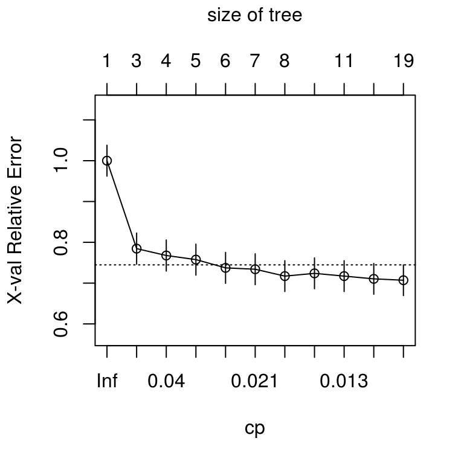

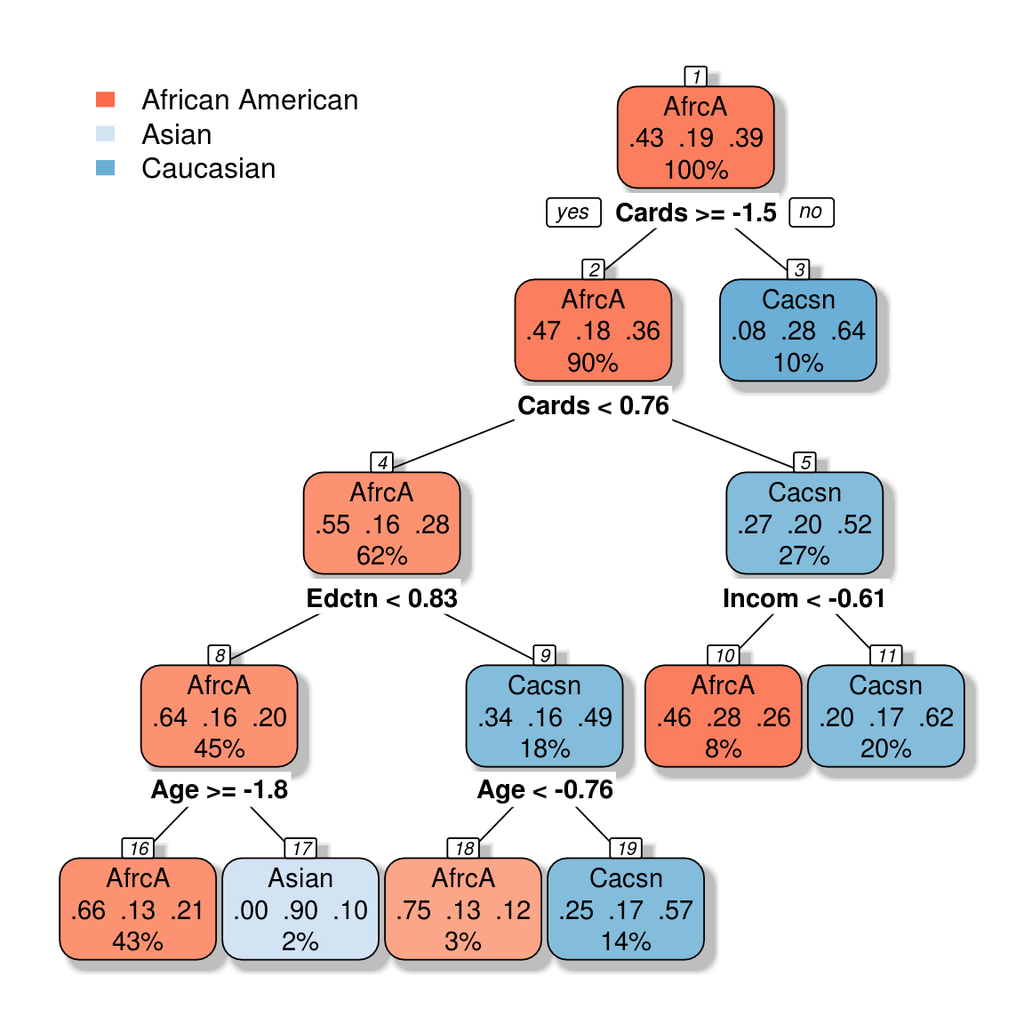

The accuracy of the pruned tree is $50\%$.

## 2.4. Logistic discrimination

In this part, we construct a multinomial logistic classifier using the $multinom$ function of the $nnet$ package. We construct the model using a training set from the total data set.

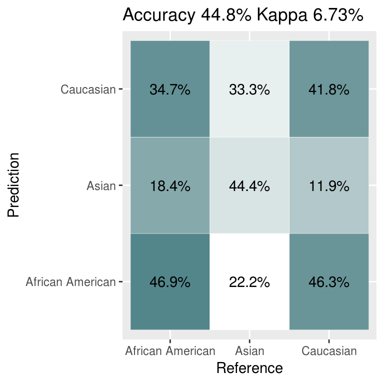

The Multinomial logistic classifier performs as poorly as the LDA classifier with an accuracy of $44.8275862\%$.

## 2.5. KNN

We perform a K-Nearest Neighbors algorithm using the $caret$ package. We split once again the data to training set and a test set and we perform a 10-fold Cross Validation using the training to obtain the best value of $K$.

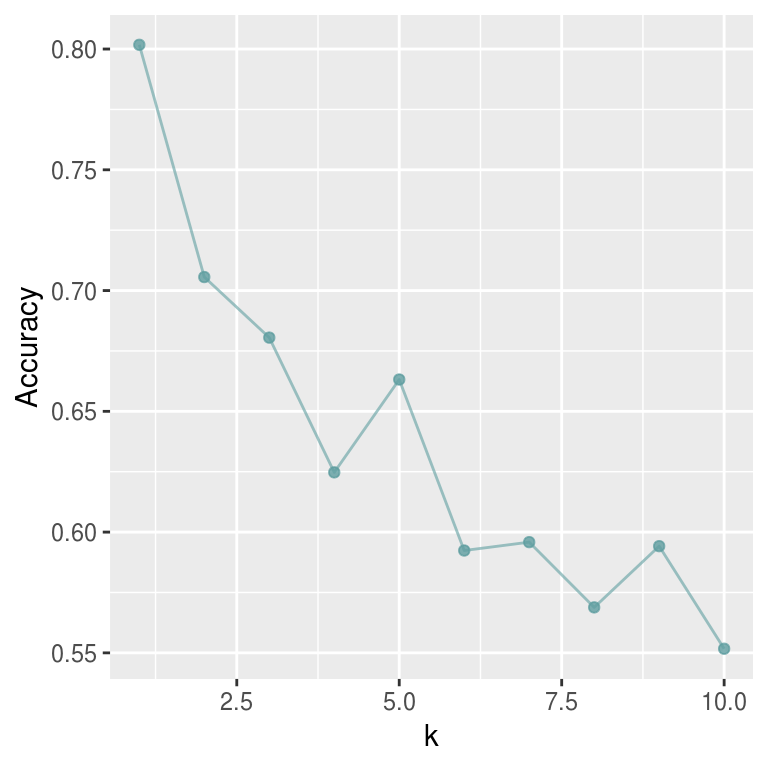

It seems that the best value is $K=1$ with a accuracy of $80.1752526\%$. We make predictions on the test test and we obtain the following confusion matrix:

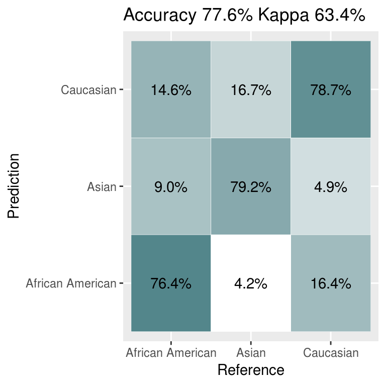

Our model have a good accuracy on the test set : $77.5862069\%$, but still doesn’t outperform SVM.

## 2.6. Conclusion

[output not shown]

# 3. Ensemble methods

## 3.1. Random Forest

We perform a random forest using a number trees to grow of $m=2 \approx \sqrt{7}$ since we use $7$ explanatory variables. We obtain the following confusion matrix :

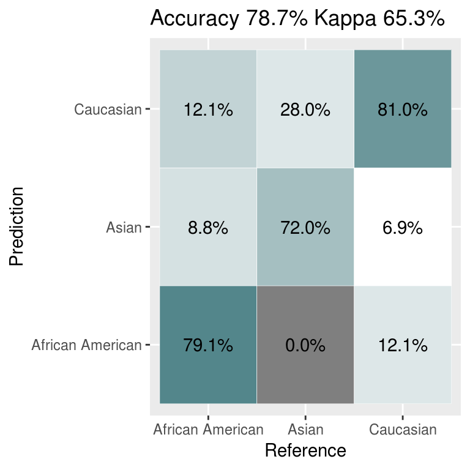

## 3.2. Gradient boosting

We make a model of gradient boosting using a total number of trees of $5000$ and an interaction depth of $6$, this results in the following confusion matrix:

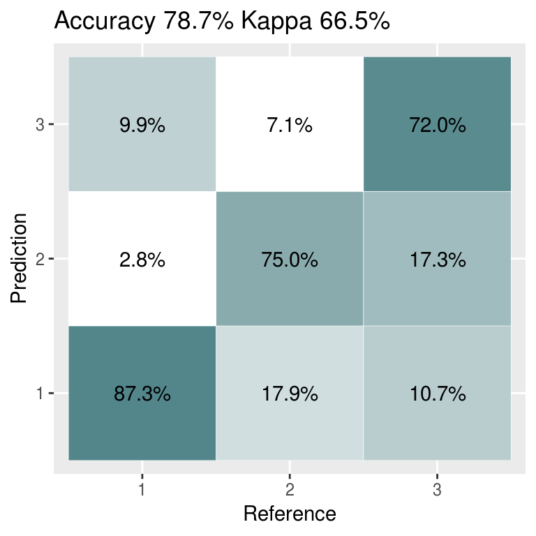

# 4. Adding more explanatory variables

In this section we introduce the remaining categorical variables $Gender \space$, $Student \space$ and $Married \space$ and we use decision rules to make the classification. Since these categorical variables are binary, we don’t need to add new dummy variables to the data.

# 4.1. Naïve Bayes

We perform a 10-fold cross validation in order to estimate the true accuracy of the Naive Bayes classifier

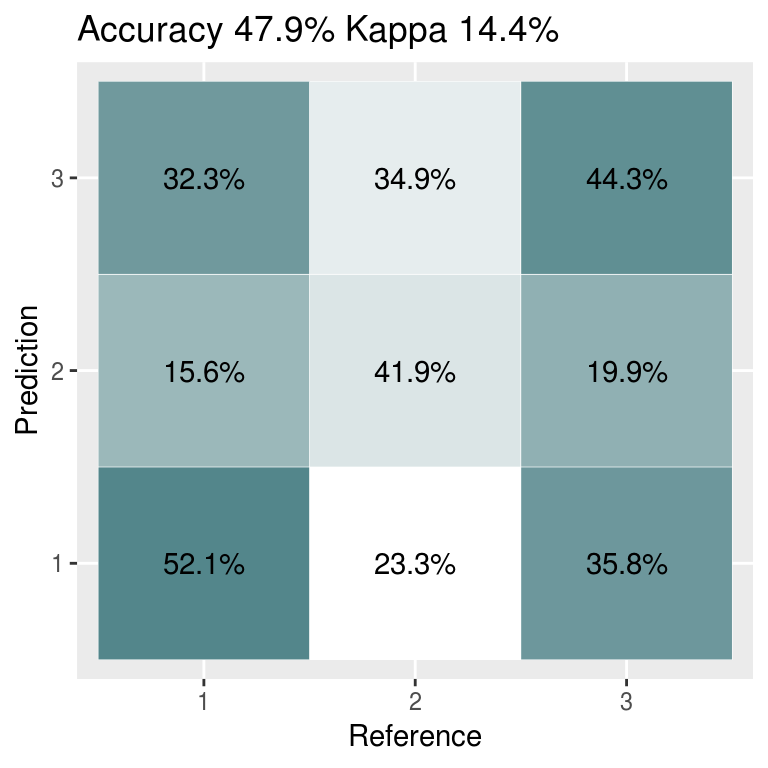

The accuracy of the Naive Bayes classifier is very low as we can see. This is probably due to the fact that the features are not independent. A typical violation of this independence assumption is the possible correlation between predictors, we can imagine that being a student is correlated with being younger and having a lower income, and being married correlated with being older and having a higher income since married people tend to be older, hence they tend to be more experienced in their jobs.

# 4.2. Decision Tree

The second decision rule model that we use is the Decision Tree model. We obtain the following Error versus Tree size for the traning set:

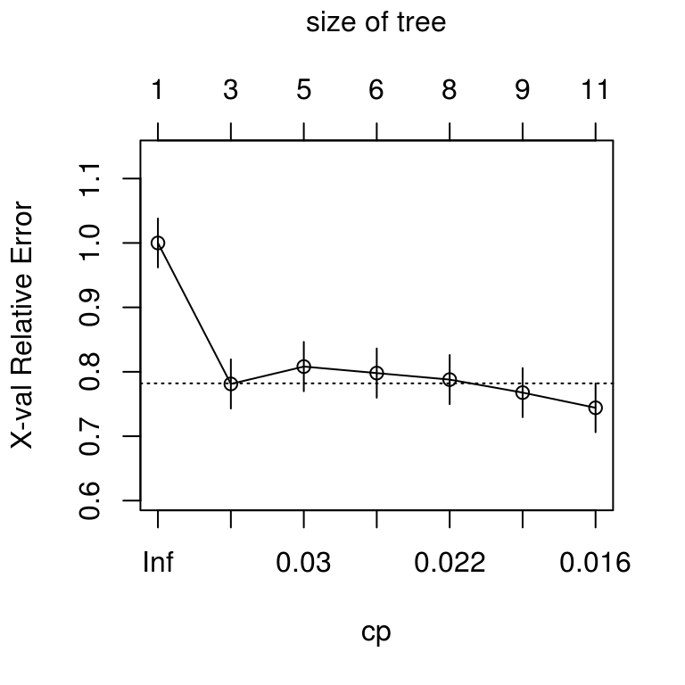

We choose the complexity parameter $cp = 0.014$ and we obtain the following confusion matrix for the test set:

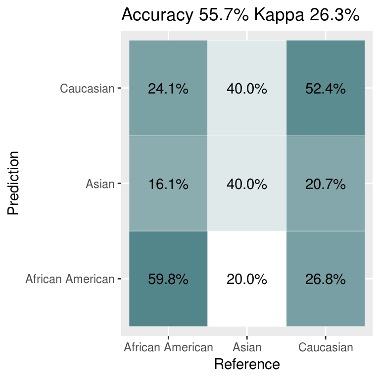

# 5. Conclusion: